# 02 Split Strategy and Dataloader Smoke Testing

This notebook consolidates the current phase-02 workflow into one notebook.

The purpose of this notebook is to move from the audited ORIGA manifest produced in Notebook `01` to a split-aware, training-ready manifest workflow. It also folds in the currently separate G1020, REFUGE, and PAPILA manifest/split notebooks so phase `02` is represented by one reproducible notebook.

This notebook should answer:

1. Can the ORIGA segmentation manifest be assigned leakage-aware train/validation/test splits?
2. Can the additional public segmentation sources be converted into the same manifest schema?
3. Can G1020, REFUGE, and PAPILA be assigned source-appropriate splits?
4. Can all split-aware source manifests be combined into one training manifest?
5. Do all image and mask paths in the combined manifest resolve locally?
6. Can the project dataloader build train/validation/test batches from the combined manifest?

Primary outputs from this notebook are written to:

`data/processed/manifests/`

and:

`data/processed/splits/`

and:

`reports/data_audit/`

This notebook does **not** train a model, compare architectures, tune augmentations, or evaluate clinical holdout data. Those steps begin in later notebooks.

```python
# 02.01 — Imports

from pathlib import Path
import importlib
import inspect
import os
import platform
import sys
import warnings

from IPython.display import Markdown, display
import matplotlib.pyplot as plt
import numpy as np
import pandas as pd
from PIL import Image, ImageDraw
import torch
```

```python
# 02.02 — Project root and source path setup

warnings.filterwarnings("default")
warnings.filterwarnings("ignore", message="IProgress not found.*")

pd.set_option("display.max_colwidth", 140)
pd.set_option("display.max_rows", 100)

def find_project_root(start_path: Path | None = None) -> Path:
    """
    Walk upward from the current location until the project root is found.

    The project root is identified by the presence of:
    - README.md
    - configs/
    - src/
    """
    start_path = Path(start_path or Path.cwd()).resolve()

    for candidate in [start_path, *start_path.parents]:
        if (
            (candidate / "README.md").exists()
            and (candidate / "configs").exists()
            and (candidate / "src").exists()
        ):
            return candidate

    raise FileNotFoundError(
        "Could not locate project root. Expected README.md, configs/, and src/."
    )

PROJECT_ROOT = find_project_root()
SRC_PATH = PROJECT_ROOT / "src"

os.chdir(PROJECT_ROOT)

if str(SRC_PATH) not in sys.path:
    sys.path.insert(0, str(SRC_PATH))

PROJECT_ROOT, SRC_PATH
```

```
(PosixPath('/sfs/gpfs/tardis/home/gsr3qz/Documents/MSDS/CAPSTONE/GitHub/Automated-Glaucoma-Screening-Using-AI-Enhanced-Ophthalmoscopy'),
 PosixPath('/sfs/gpfs/tardis/home/gsr3qz/Documents/MSDS/CAPSTONE/GitHub/Automated-Glaucoma-Screening-Using-AI-Enhanced-Ophthalmoscopy/src'))
```

```python
# 02.03 — Environment and phase-02 directory setup

DATA_ROOT = PROJECT_ROOT / "data"
KAGGLE_DATA_ROOT = DATA_ROOT / "external" / "kaggle"
MANIFEST_DIR = DATA_ROOT / "processed" / "manifests"
SPLIT_DIR = DATA_ROOT / "processed" / "splits"
REPORTS_DIR = PROJECT_ROOT / "reports" / "data_audit"
STANDARDIZED_MASK_DIR = DATA_ROOT / "processed" / "standardized_masks"
PAPILA_MASK_DIR = DATA_ROOT / "processed" / "papila_masks"

for directory in [MANIFEST_DIR, SPLIT_DIR, REPORTS_DIR, STANDARDIZED_MASK_DIR, PAPILA_MASK_DIR]:
    directory.mkdir(parents=True, exist_ok=True)

environment_df = pd.DataFrame(
    [
        {
            "check": "Project root",
            "status": "OK" if PROJECT_ROOT.exists() else "CHECK",
            "value": str(PROJECT_ROOT),
        },
        {
            "check": "Notebook Python executable",
            "status": "OK" if "glaucoma-capstone" in sys.executable else "CHECK",
            "value": sys.executable,
        },
        {
            "check": "Python version",
            "status": "OK",
            "value": sys.version.replace("\n", " "),
        },
        {
            "check": "PyTorch version",
            "status": "OK",
            "value": torch.__version__,
        },
        {
            "check": "CUDA availability",
            "status": "OK" if torch.cuda.is_available() else "CPU_ONLY",
            "value": f"CUDA device count: {torch.cuda.device_count()}",
        },
        {
            "check": "Manifest directory",
            "status": "OK" if MANIFEST_DIR.exists() else "CHECK",
            "value": str(MANIFEST_DIR.relative_to(PROJECT_ROOT)),
        },
        {
            "check": "Split directory",
            "status": "OK" if SPLIT_DIR.exists() else "CHECK",
            "value": str(SPLIT_DIR.relative_to(PROJECT_ROOT)),
        },
    ]
)

environment_df
```

|  | check | status | value |
| --- | --- | --- | --- |
| 0 | Project root | OK | /sfs/gpfs/tardis/home/gsr3qz/Documents/MSDS/CAPSTONE/GitHub/Automated-Glaucoma-Screening-Using-AI-Enhanced-Ophthalmoscopy |
| 1 | Notebook Python executable | OK | /home/gsr3qz/.conda/envs/glaucoma-capstone/bin/python |
| 2 | Python version | OK | 3.11.15 \| packaged by conda-forge \| (main, Jun 11 2026, 03:34:02) [GCC 14.3.0] |
| 3 | PyTorch version | OK | 2.4.0 |
| 4 | CUDA availability | OK | CUDA device count: 1 |
| 5 | Manifest directory | OK | data/processed/manifests |
| 6 | Split directory | OK | data/processed/splits |

```python
# 02.04 — Core project module import check

module_names = [
    "glaucoma_segmentation.data.manifest",
    "glaucoma_segmentation.data.split_strategy",
    "glaucoma_segmentation.data.segmentation_dataset",
    "glaucoma_segmentation.data.dataloaders",
]

module_check_rows = []

for module_name in module_names:
    try:
        module = importlib.import_module(module_name)
        module_check_rows.append(
            {
                "module": module_name,
                "status": "OK",
                "source_file": getattr(module, "__file__", "[unknown]"),
            }
        )
    except Exception as exc:
        module_check_rows.append(
            {
                "module": module_name,
                "status": "FAIL",
                "source_file": f"{type(exc).__name__}: {exc}",
            }
        )

module_check_df = pd.DataFrame(module_check_rows)
module_check_df
```

|  | module | status | source_file |
| --- | --- | --- | --- |
| 0 | glaucoma_segmentation.data.manifest | OK | /sfs/gpfs/tardis/home/gsr3qz/Documents/MSDS/CAPSTONE/GitHub/Automated-Glaucoma-Screening-Using-AI-Enhanced-Ophthalmoscopy/src/glaucoma_s... |
| 1 | glaucoma_segmentation.data.split_strategy | OK | /sfs/gpfs/tardis/home/gsr3qz/Documents/MSDS/CAPSTONE/GitHub/Automated-Glaucoma-Screening-Using-AI-Enhanced-Ophthalmoscopy/src/glaucoma_s... |
| 2 | glaucoma_segmentation.data.segmentation_dataset | OK | /sfs/gpfs/tardis/home/gsr3qz/Documents/MSDS/CAPSTONE/GitHub/Automated-Glaucoma-Screening-Using-AI-Enhanced-Ophthalmoscopy/src/glaucoma_s... |
| 3 | glaucoma_segmentation.data.dataloaders | OK | /sfs/gpfs/tardis/home/gsr3qz/Documents/MSDS/CAPSTONE/GitHub/Automated-Glaucoma-Screening-Using-AI-Enhanced-Ophthalmoscopy/src/glaucoma_s... |

```python
# 02.05 — Project helper imports after source path setup

from glaucoma_segmentation.data.split_strategy import (
    SplitConfig,
    assign_grouped_splits,
    check_group_leakage,
    split_summary,
)
from glaucoma_segmentation.data.dataloaders import make_segmentation_dataloaders

display(
    pd.DataFrame(
        [
            {
                "helper": "SplitConfig",
                "status": "OK",
                "signature": str(inspect.signature(SplitConfig)),
            },
            {
                "helper": "assign_grouped_splits",
                "status": "OK",
                "signature": str(inspect.signature(assign_grouped_splits)),
            },
            {
                "helper": "make_segmentation_dataloaders",
                "status": "OK",
                "signature": str(inspect.signature(make_segmentation_dataloaders)),
            },
        ]
    )
)
```

|  | helper | status | signature |
| --- | --- | --- | --- |
| 0 | SplitConfig | OK | (train_size: 'float' = 0.7, val_size: 'float' = 0.15, test_size: 'float' = 0.15, group_col: 'str' = 'split_group_id', split_col: 'str' =... |
| 1 | assign_grouped_splits | OK | (manifest_df: 'pd.DataFrame', *, config: 'SplitConfig \| None' = None, group_col: 'str \| None' = None, split_col: 'str \| None' = None, se... |
| 2 | make_segmentation_dataloaders | OK | (manifest_path: 'str \| Path' = 'data/processed/manifests/combined_segmentation_manifest_with_splits.csv', batch_size: 'int' = 4, image_s... |

## 02.06 — Phase-02 configuration

The split target is 70/15/15 train/validation/test.

For public datasets without official splits, this notebook uses group-aware random splits keyed on `split_group_id`.

REFUGE includes official train/validation/test folders, so the default is to honor the official REFUGE split rather than re-splitting it.

```python
# 02.07 — Constants and manifest schema

SPLIT_SEED = 42
REFUGE_MODE = "official"  # "official" or "group_random"
EXPERT = 1                # PAPILA expert contour set to rasterize

SPLIT_CONFIG = SplitConfig(
    train_size=0.70,
    val_size=0.15,
    test_size=0.15,
    group_col="split_group_id",
    seed=SPLIT_SEED,
)

IMAGE_EXTENSIONS = {".jpg", ".jpeg", ".png", ".bmp", ".tif", ".tiff"}

MANIFEST_COLUMNS = [
    "dataset_key",
    "source_dataset",
    "file_id",
    "image_path",
    "mask_path",
    "image_relative_path",
    "mask_relative_path",
    "image_file_name",
    "mask_file_name",
    "mask_encoding",
    "background_value",
    "structure_value_1",
    "structure_value_2",
    "split_group_id",
    "include_in_first_pass",
    "qa_status",
    "notes",
]

CORE_COMBINED_COLUMNS = [
    "dataset_key",
    "source_dataset",
    "file_id",
    "image_path",
    "mask_path",
    "split_group_id",
    "split",
]

pd.DataFrame(
    [
        {"setting": "SPLIT_SEED", "value": SPLIT_SEED},
        {"setting": "train_size", "value": SPLIT_CONFIG.train_size},
        {"setting": "val_size", "value": SPLIT_CONFIG.val_size},
        {"setting": "test_size", "value": SPLIT_CONFIG.test_size},
        {"setting": "group_col", "value": SPLIT_CONFIG.group_col},
        {"setting": "REFUGE_MODE", "value": REFUGE_MODE},
        {"setting": "PAPILA_EXPERT", "value": EXPERT},
    ]
)
```

|  | setting | value |
| --- | --- | --- |
| 0 | SPLIT_SEED | 42 |
| 1 | train_size | 0.7 |
| 2 | val_size | 0.15 |
| 3 | test_size | 0.15 |
| 4 | group_col | split_group_id |
| 5 | REFUGE_MODE | official |
| 6 | PAPILA_EXPERT | 1 |

## 02.08 — Input handoff from Notebook 01

Notebook `01` created the ORIGA manifest. This notebook begins from that artifact and adds split assignments.

```python
# 02.09 — Read ORIGA manifest from Notebook 01

origa_manifest_path = MANIFEST_DIR / "origa_segmentation_manifest.csv"

origa_manifest = pd.read_csv(
    origa_manifest_path,
    dtype={
        "file_id": str,
        "split_group_id": str,
    },
)

origa_input_check_df = pd.DataFrame(
    [
        {
            "input": "origa_segmentation_manifest.csv",
            "path": str(origa_manifest_path.relative_to(PROJECT_ROOT)),
            "exists": origa_manifest_path.exists(),
            "rows": len(origa_manifest),
            "columns": list(origa_manifest.columns),
        }
    ]
)

origa_input_check_df
```

|  | input | path | exists | rows | columns |
| --- | --- | --- | --- | --- | --- |
| 0 | origa_segmentation_manifest.csv | data/processed/manifests/origa_segmentation_manifest.csv | True | 650 | [dataset_key, source_dataset, file_id, image_path, mask_path, image_relative_path, mask_relative_path, image_file_name, mask_file_name, ... |

```python
# 02.10 — Assign ORIGA leakage-aware splits

origa_manifest_with_splits = assign_grouped_splits(origa_manifest, config=SPLIT_CONFIG)

origa_split_assignments = (
    origa_manifest_with_splits[["split_group_id", "split"]]
    .drop_duplicates()
    .sort_values("split_group_id")
    .reset_index(drop=True)
)

origa_split_assignments_path = SPLIT_DIR / "origa_split_assignments.csv"
origa_manifest_with_splits_path = MANIFEST_DIR / "origa_segmentation_manifest_with_splits.csv"

origa_split_assignments.to_csv(origa_split_assignments_path, index=False)
origa_manifest_with_splits.to_csv(origa_manifest_with_splits_path, index=False)

origa_split_summary = (
    origa_manifest_with_splits
    .groupby("split")
    .size()
    .reindex(["train", "val", "test"])
    .fillna(0)
    .astype(int)
    .reset_index(name="n_records")
)

origa_split_summary
```

|  | split | n_records |
| --- | --- | --- |
| 0 | train | 455 |
| 1 | val | 98 |
| 2 | test | 97 |

```python
# 02.11 — Validate ORIGA split assignment

def validate_split_assignment(
    manifest_before: pd.DataFrame,
    manifest_after: pd.DataFrame,
    source_name: str,
    group_col: str = "split_group_id",
    split_col: str = "split",
) -> pd.DataFrame:
    leakage_df = check_group_leakage(
        manifest_after,
        group_col=group_col,
        split_col=split_col,
    )

    validation_df = pd.DataFrame(
        [
            {
                "source_dataset": source_name,
                "check": "manifest_row_count_preserved",
                "passed": len(manifest_after) == len(manifest_before),
                "value": len(manifest_after),
                "expected": len(manifest_before),
            },
            {
                "source_dataset": source_name,
                "check": "no_missing_split_assignments",
                "passed": manifest_after[split_col].isna().sum() == 0,
                "value": int(manifest_after[split_col].isna().sum()),
                "expected": 0,
            },
            {
                "source_dataset": source_name,
                "check": "no_split_group_crosses_splits",
                "passed": len(leakage_df) == 0,
                "value": len(leakage_df),
                "expected": 0,
            },
        ]
    )

    return validation_df

origa_split_validation = validate_split_assignment(
    manifest_before=origa_manifest,
    manifest_after=origa_manifest_with_splits,
    source_name="ORIGA",
)

origa_split_validation_path = SPLIT_DIR / "origa_split_validation_summary.csv"
origa_split_validation.to_csv(origa_split_validation_path, index=False)

origa_split_validation
```

|  | source_dataset | check | passed | value | expected |
| --- | --- | --- | --- | --- | --- |
| 0 | ORIGA | manifest_row_count_preserved | True | 650 | 650 |
| 1 | ORIGA | no_missing_split_assignments | True | 0 | 0 |
| 2 | ORIGA | no_split_group_crosses_splits | True | 0 | 0 |

## 02.12 — Manifest helpers for additional public sources

The next cells fold the existing `02a` work into this single phase-02 notebook.

G1020 and REFUGE are paired by image/mask filename stem. PAPILA contours are rasterized into `{0,1,2}` masks so all sources can use the same dataloader.

```python
# 02.13 — File discovery and manifest helper functions

def project_relative(path: str | Path) -> str:
    return Path(path).resolve().relative_to(PROJECT_ROOT).as_posix()

def image_files(folder: Path) -> dict[str, Path]:
    if not folder.exists():
        return {}
    return {
        path.stem: path
        for path in sorted(folder.iterdir())
        if path.is_file() and path.suffix.lower() in IMAGE_EXTENSIONS
    }

def pair_image_mask_by_stem(image_dir: Path, mask_dir: Path) -> tuple[list[dict[str, Path | str]], dict[str, int]]:
    images = image_files(image_dir)
    masks = image_files(mask_dir)

    paired_stems = sorted(set(images) & set(masks))

    records = [
        {
            "file_id": stem,
            "image_abs": images[stem],
            "mask_abs": masks[stem],
        }
        for stem in paired_stems
    ]

    stats = {
        "n_images": len(images),
        "n_masks": len(masks),
        "n_pairs": len(records),
        "n_unpaired_images": len(set(images) - set(masks)),
        "n_unpaired_masks": len(set(masks) - set(images)),
    }

    return records, stats

def standardize_mask_array(mask_path: Path) -> tuple[np.ndarray, list[int], list[int], str]:
    raw = np.asarray(Image.open(mask_path))

    if raw.ndim == 3:
        raw = np.asarray(Image.open(mask_path).convert("L"))

    raw = raw.astype(np.uint8)
    raw_values = sorted(np.unique(raw).astype(int).tolist())

    if set(raw_values).issubset({0, 1, 2}):
        return raw, raw_values, raw_values, "already_0_1_2"

    nonzero_values = [value for value in raw_values if value != 0]
    standardized = np.zeros_like(raw, dtype=np.uint8)

    if len(nonzero_values) == 1:
        standardized[raw == nonzero_values[0]] = 1
        status = "mapped_single_nonzero_value_to_disc"
    elif len(nonzero_values) >= 2:
        lower_structure = nonzero_values[0]
        upper_structures = nonzero_values[1:]
        standardized[raw == lower_structure] = 1
        standardized[np.isin(raw, upper_structures)] = 2
        status = "mapped_ordered_nonzero_values_to_disc_and_cup"
    else:
        status = "empty_mask_no_nonzero_values"

    standardized_values = sorted(np.unique(standardized).astype(int).tolist())
    return standardized, raw_values, standardized_values, status

def write_standardized_mask(raw_mask_path: Path, source_slug: str, file_id: str) -> tuple[Path, dict[str, object]]:
    standardized_mask_dir = STANDARDIZED_MASK_DIR / source_slug
    standardized_mask_dir.mkdir(parents=True, exist_ok=True)

    standardized_mask, raw_values, standardized_values, status = standardize_mask_array(raw_mask_path)
    output_path = standardized_mask_dir / f"{file_id}.png"
    Image.fromarray(standardized_mask).save(output_path)

    metadata = {
        "raw_mask_path": project_relative(raw_mask_path),
        "standardized_mask_path": project_relative(output_path),
        "raw_mask_unique_values": raw_values,
        "standardized_mask_unique_values": standardized_values,
        "standardization_status": status,
    }

    return output_path, metadata

def manifest_row(
    *,
    dataset_key: str,
    source_dataset: str,
    file_id: str,
    image_abs: Path,
    mask_abs: Path,
    split_group_id: str,
    qa_status: str,
    notes: str,
    extra: dict[str, object] | None = None,
) -> dict[str, object]:
    image_rel = project_relative(image_abs)
    mask_rel = project_relative(mask_abs)

    row = {
        "dataset_key": dataset_key,
        "source_dataset": source_dataset,
        "file_id": str(file_id),
        "image_path": image_rel,
        "mask_path": mask_rel,
        "image_relative_path": image_rel,
        "mask_relative_path": mask_rel,
        "image_file_name": Path(image_abs).name,
        "mask_file_name": Path(mask_abs).name,
        "mask_encoding": "multiclass_values_0_1_2",
        "background_value": 0,
        "structure_value_1": 1,
        "structure_value_2": 2,
        "split_group_id": str(split_group_id),
        "include_in_first_pass": True,
        "qa_status": qa_status,
        "notes": notes,
    }

    if extra:
        row.update(extra)

    return row
```

```python
# 02.14 — Visual QA helper for source manifests

def visual_qa_sample(
    manifest_df: pd.DataFrame,
    source_slug: str,
    n: int = 4,
) -> pd.DataFrame:
    if manifest_df.empty:
        return pd.DataFrame(
            columns=[
                "source_dataset",
                "file_id",
                "image_size",
                "mask_shape",
                "sizes_match",
                "mask_unique_values",
            ]
        )

    sample_df = manifest_df.sample(
        n=min(n, len(manifest_df)),
        random_state=SPLIT_SEED,
    ).reset_index(drop=True)

    qa_rows = []

    fig, axes = plt.subplots(
        len(sample_df),
        3,
        figsize=(11, 3.2 * len(sample_df)),
    )

    if len(sample_df) == 1:
        axes = axes[None, :]

    for row_idx, row in sample_df.iterrows():
        image = Image.open(PROJECT_ROOT / row["image_path"]).convert("RGB")
        mask = np.asarray(Image.open(PROJECT_ROOT / row["mask_path"]))

        if mask.ndim == 3:
            mask = mask[..., 0]

        unique_values = sorted(np.unique(mask).astype(int).tolist())
        image_for_overlay = np.asarray(image.resize(mask.shape[::-1]))

        qa_rows.append(
            {
                "source_dataset": row["source_dataset"],
                "file_id": row["file_id"],
                "image_size": image.size,
                "mask_shape": mask.shape,
                "sizes_match": image.size == mask.shape[::-1],
                "mask_unique_values": unique_values,
            }
        )

        axes[row_idx, 0].imshow(image_for_overlay)
        axes[row_idx, 0].set_title(f"{row['source_dataset']} {row['file_id']}")

        axes[row_idx, 1].imshow(mask)
        axes[row_idx, 1].set_title(f"mask {unique_values}")

        axes[row_idx, 2].imshow(image_for_overlay)
        axes[row_idx, 2].imshow(mask, alpha=0.4)
        axes[row_idx, 2].set_title("overlay")

        for axis in axes[row_idx]:
            axis.axis("off")

    plt.tight_layout()
    plt.show()

    qa_df = pd.DataFrame(qa_rows)
    qa_path = REPORTS_DIR / f"{source_slug}_visual_qa_summary.csv"
    qa_df.to_csv(qa_path, index=False)

    return qa_df
```

```python
# 02.15 — Locate public dataset source folders

bundle_root = KAGGLE_DATA_ROOT / "glaucoma_fundus_imaging_bundle"
papila_download_root = KAGGLE_DATA_ROOT / "papila"

def find_papila_root(start_dir: Path) -> Path | None:
    candidates = []

    if (start_dir / "FundusImages").exists() and (start_dir / "ExpertsSegmentations" / "Contours").exists():
        candidates.append(start_dir)

    if start_dir.exists():
        for candidate in sorted(start_dir.rglob("*")):
            if (
                candidate.is_dir()
                and (candidate / "FundusImages").exists()
                and (candidate / "ExpertsSegmentations" / "Contours").exists()
            ):
                candidates.append(candidate)

    return candidates[0] if candidates else None

papila_root = find_papila_root(papila_download_root)

source_location_df = pd.DataFrame(
    [
        {
            "source_dataset": "G1020",
            "path": str((bundle_root / "G1020").relative_to(PROJECT_ROOT)),
            "exists": (bundle_root / "G1020").exists(),
        },
        {
            "source_dataset": "REFUGE",
            "path": str((bundle_root / "REFUGE").relative_to(PROJECT_ROOT)),
            "exists": (bundle_root / "REFUGE").exists(),
        },
        {
            "source_dataset": "PAPILA",
            "path": str(papila_root.relative_to(PROJECT_ROOT)) if papila_root else "[not found]",
            "exists": papila_root is not None,
        },
    ]
)

source_location_df
```

|  | source_dataset | path | exists |
| --- | --- | --- | --- |
| 0 | G1020 | data/external/kaggle/glaucoma_fundus_imaging_bundle/G1020 | True |
| 1 | REFUGE | data/external/kaggle/glaucoma_fundus_imaging_bundle/REFUGE | True |
| 2 | PAPILA | data/external/kaggle/papila/PapilaDB-PAPILA-17f8fa7746adb20275b5b6a0d99dc9dfe3007e9f | True |

## 02.16 — G1020 manifest

G1020 images and masks are paired by filename stem. Masks are written to a project-standardized `{0,1,2}` PNG location before the manifest is saved.

```python
# 02.17 — Build G1020 segmentation manifest

g1020_records, g1020_pairing_stats = pair_image_mask_by_stem(
    image_dir=bundle_root / "G1020" / "Images",
    mask_dir=bundle_root / "G1020" / "Masks",
)

g1020_manifest_rows = []
g1020_standardization_rows = []

for record in g1020_records:
    standardized_mask_path, standardization_metadata = write_standardized_mask(
        raw_mask_path=Path(record["mask_abs"]),
        source_slug="g1020",
        file_id=str(record["file_id"]),
    )

    g1020_standardization_rows.append(
        {
            "source_dataset": "G1020",
            "file_id": record["file_id"],
            **standardization_metadata,
        }
    )

    g1020_manifest_rows.append(
        manifest_row(
            dataset_key="glaucoma_fundus_imaging_bundle",
            source_dataset="G1020",
            file_id=str(record["file_id"]),
            image_abs=Path(record["image_abs"]),
            mask_abs=standardized_mask_path,
            split_group_id=f"G1020_{record['file_id']}",
            qa_status="paired_standardized_and_visual_sample_reviewed",
            notes="G1020 image/mask pair matched by file ID; mask standardized to project {0,1,2} convention.",
        )
    )

g1020_manifest = pd.DataFrame(g1020_manifest_rows)
if not g1020_manifest.empty:
    g1020_manifest = g1020_manifest[MANIFEST_COLUMNS]

g1020_manifest_path = MANIFEST_DIR / "g1020_segmentation_manifest.csv"
g1020_standardization_path = REPORTS_DIR / "g1020_mask_standardization_summary.csv"

g1020_manifest.to_csv(g1020_manifest_path, index=False)
pd.DataFrame(g1020_standardization_rows).to_csv(g1020_standardization_path, index=False)

display(pd.DataFrame([{"source_dataset": "G1020", **g1020_pairing_stats}]))
display(g1020_manifest.head())
```

|  | source_dataset | n_images | n_masks | n_pairs | n_unpaired_images | n_unpaired_masks |
| --- | --- | --- | --- | --- | --- | --- |
| 0 | G1020 | 1020 | 1020 | 1020 | 0 | 0 |

|  | dataset_key | source_dataset | file_id | image_path | mask_path | image_relative_path | mask_relative_path | image_file_name | mask_file_name | mask_encoding | background_value | structure_value_1 | structure_value_2 | split_group_id | include_in_first_pass | qa_status | notes |
| --- | --- | --- | --- | --- | --- | --- | --- | --- | --- | --- | --- | --- | --- | --- | --- | --- | --- |
| 0 | glaucoma_fundus_imaging_bundle | G1020 | image_0 | data/external/kaggle/glaucoma_fundus_imaging_bundle/G1020/Images/image_0.jpg | data/processed/standardized_masks/g1020/image_0.png | data/external/kaggle/glaucoma_fundus_imaging_bundle/G1020/Images/image_0.jpg | data/processed/standardized_masks/g1020/image_0.png | image_0.jpg | image_0.png | multiclass_values_0_1_2 | 0 | 1 | 2 | G1020_image_0 | True | paired_standardized_and_visual_sample_reviewed | G1020 image/mask pair matched by file ID; mask standardized to project {0,1,2} convention. |
| 1 | glaucoma_fundus_imaging_bundle | G1020 | image_1 | data/external/kaggle/glaucoma_fundus_imaging_bundle/G1020/Images/image_1.jpg | data/processed/standardized_masks/g1020/image_1.png | data/external/kaggle/glaucoma_fundus_imaging_bundle/G1020/Images/image_1.jpg | data/processed/standardized_masks/g1020/image_1.png | image_1.jpg | image_1.png | multiclass_values_0_1_2 | 0 | 1 | 2 | G1020_image_1 | True | paired_standardized_and_visual_sample_reviewed | G1020 image/mask pair matched by file ID; mask standardized to project {0,1,2} convention. |
| 2 | glaucoma_fundus_imaging_bundle | G1020 | image_10 | data/external/kaggle/glaucoma_fundus_imaging_bundle/G1020/Images/image_10.jpg | data/processed/standardized_masks/g1020/image_10.png | data/external/kaggle/glaucoma_fundus_imaging_bundle/G1020/Images/image_10.jpg | data/processed/standardized_masks/g1020/image_10.png | image_10.jpg | image_10.png | multiclass_values_0_1_2 | 0 | 1 | 2 | G1020_image_10 | True | paired_standardized_and_visual_sample_reviewed | G1020 image/mask pair matched by file ID; mask standardized to project {0,1,2} convention. |
| 3 | glaucoma_fundus_imaging_bundle | G1020 | image_1000 | data/external/kaggle/glaucoma_fundus_imaging_bundle/G1020/Images/image_1000.jpg | data/processed/standardized_masks/g1020/image_1000.png | data/external/kaggle/glaucoma_fundus_imaging_bundle/G1020/Images/image_1000.jpg | data/processed/standardized_masks/g1020/image_1000.png | image_1000.jpg | image_1000.png | multiclass_values_0_1_2 | 0 | 1 | 2 | G1020_image_1000 | True | paired_standardized_and_visual_sample_reviewed | G1020 image/mask pair matched by file ID; mask standardized to project {0,1,2} convention. |
| 4 | glaucoma_fundus_imaging_bundle | G1020 | image_1001 | data/external/kaggle/glaucoma_fundus_imaging_bundle/G1020/Images/image_1001.jpg | data/processed/standardized_masks/g1020/image_1001.png | data/external/kaggle/glaucoma_fundus_imaging_bundle/G1020/Images/image_1001.jpg | data/processed/standardized_masks/g1020/image_1001.png | image_1001.jpg | image_1001.png | multiclass_values_0_1_2 | 0 | 1 | 2 | G1020_image_1001 | True | paired_standardized_and_visual_sample_reviewed | G1020 image/mask pair matched by file ID; mask standardized to project {0,1,2} convention. |

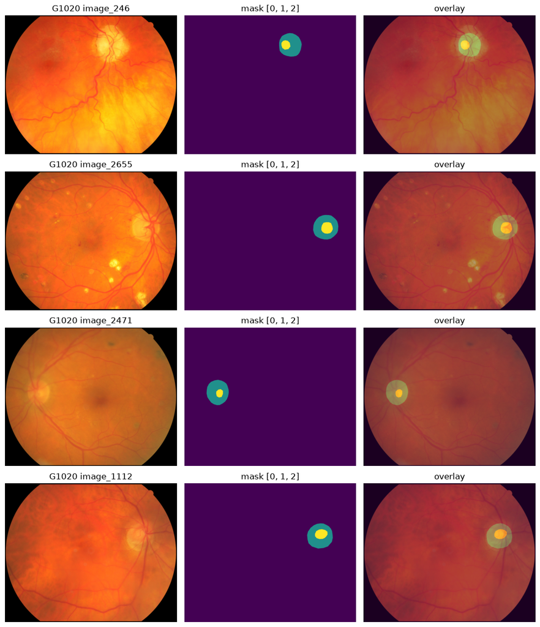

|  | source_dataset | file_id | image_size | mask_shape | sizes_match | mask_unique_values |
| --- | --- | --- | --- | --- | --- | --- |
| 0 | G1020 | image_246 | (3005, 2425) | (2425, 3005) | True | [0, 1, 2] |
| 1 | G1020 | image_2655 | (3005, 2425) | (2425, 3005) | True | [0, 1, 2] |
| 2 | G1020 | image_2471 | (3004, 2423) | (2423, 3004) | True | [0, 1, 2] |
| 3 | G1020 | image_1112 | (3005, 2424) | (2424, 3005) | True | [0, 1, 2] |

```python
# 02.18 — G1020 visual QA sample

g1020_visual_qa = visual_qa_sample(
    manifest_df=g1020_manifest,
    source_slug="g1020",
    n=4,
)

g1020_visual_qa
```

## 02.19 — REFUGE manifest

REFUGE images and masks are paired inside the official `train`, `val`, and `test` folders. The official split is preserved in `refuge_official_split`.

```python
# 02.20 — Build REFUGE segmentation manifest

refuge_manifest_rows = []
refuge_pairing_rows = []
refuge_standardization_rows = []

for official_split in ["train", "val", "test"]:
    records, stats = pair_image_mask_by_stem(
        image_dir=bundle_root / "REFUGE" / official_split / "Images",
        mask_dir=bundle_root / "REFUGE" / official_split / "Masks",
    )

    refuge_pairing_rows.append(
        {
            "source_dataset": "REFUGE",
            "official_split": official_split,
            **stats,
        }
    )

    for record in records:
        file_id = str(record["file_id"])
        standardized_file_id = f"{official_split}_{file_id}"

        standardized_mask_path, standardization_metadata = write_standardized_mask(
            raw_mask_path=Path(record["mask_abs"]),
            source_slug="refuge",
            file_id=standardized_file_id,
        )

        refuge_standardization_rows.append(
            {
                "source_dataset": "REFUGE",
                "official_split": official_split,
                "file_id": file_id,
                **standardization_metadata,
            }
        )

        refuge_manifest_rows.append(
            manifest_row(
                dataset_key="glaucoma_fundus_imaging_bundle",
                source_dataset="REFUGE",
                file_id=file_id,
                image_abs=Path(record["image_abs"]),
                mask_abs=standardized_mask_path,
                split_group_id=f"REFUGE_{official_split}_{file_id}",
                qa_status="paired_standardized_and_visual_sample_reviewed",
                notes="REFUGE image/mask pair matched by file ID within official split; mask standardized to project {0,1,2} convention.",
                extra={"refuge_official_split": official_split},
            )
        )

refuge_manifest = pd.DataFrame(refuge_manifest_rows)
if not refuge_manifest.empty:
    refuge_manifest = refuge_manifest[MANIFEST_COLUMNS + ["refuge_official_split"]]

refuge_manifest_path = MANIFEST_DIR / "refuge_segmentation_manifest.csv"
refuge_standardization_path = REPORTS_DIR / "refuge_mask_standardization_summary.csv"

refuge_manifest.to_csv(refuge_manifest_path, index=False)
pd.DataFrame(refuge_standardization_rows).to_csv(refuge_standardization_path, index=False)

display(pd.DataFrame(refuge_pairing_rows))
display(refuge_manifest.head())
```

|  | source_dataset | official_split | n_images | n_masks | n_pairs | n_unpaired_images | n_unpaired_masks |
| --- | --- | --- | --- | --- | --- | --- | --- |
| 0 | REFUGE | train | 400 | 400 | 400 | 0 | 0 |
| 1 | REFUGE | val | 400 | 400 | 400 | 0 | 0 |
| 2 | REFUGE | test | 400 | 400 | 400 | 0 | 0 |

|  | dataset_key | source_dataset | file_id | image_path | mask_path | image_relative_path | mask_relative_path | image_file_name | mask_file_name | mask_encoding | background_value | structure_value_1 | structure_value_2 | split_group_id | include_in_first_pass | qa_status | notes | refuge_official_split |
| --- | --- | --- | --- | --- | --- | --- | --- | --- | --- | --- | --- | --- | --- | --- | --- | --- | --- | --- |
| 0 | glaucoma_fundus_imaging_bundle | REFUGE | g0001 | data/external/kaggle/glaucoma_fundus_imaging_bundle/REFUGE/train/Images/g0001.jpg | data/processed/standardized_masks/refuge/train_g0001.png | data/external/kaggle/glaucoma_fundus_imaging_bundle/REFUGE/train/Images/g0001.jpg | data/processed/standardized_masks/refuge/train_g0001.png | g0001.jpg | train_g0001.png | multiclass_values_0_1_2 | 0 | 1 | 2 | REFUGE_train_g0001 | True | paired_standardized_and_visual_sample_reviewed | REFUGE image/mask pair matched by file ID within official split; mask standardized to project {0,1,2} convention. | train |
| 1 | glaucoma_fundus_imaging_bundle | REFUGE | g0002 | data/external/kaggle/glaucoma_fundus_imaging_bundle/REFUGE/train/Images/g0002.jpg | data/processed/standardized_masks/refuge/train_g0002.png | data/external/kaggle/glaucoma_fundus_imaging_bundle/REFUGE/train/Images/g0002.jpg | data/processed/standardized_masks/refuge/train_g0002.png | g0002.jpg | train_g0002.png | multiclass_values_0_1_2 | 0 | 1 | 2 | REFUGE_train_g0002 | True | paired_standardized_and_visual_sample_reviewed | REFUGE image/mask pair matched by file ID within official split; mask standardized to project {0,1,2} convention. | train |
| 2 | glaucoma_fundus_imaging_bundle | REFUGE | g0003 | data/external/kaggle/glaucoma_fundus_imaging_bundle/REFUGE/train/Images/g0003.jpg | data/processed/standardized_masks/refuge/train_g0003.png | data/external/kaggle/glaucoma_fundus_imaging_bundle/REFUGE/train/Images/g0003.jpg | data/processed/standardized_masks/refuge/train_g0003.png | g0003.jpg | train_g0003.png | multiclass_values_0_1_2 | 0 | 1 | 2 | REFUGE_train_g0003 | True | paired_standardized_and_visual_sample_reviewed | REFUGE image/mask pair matched by file ID within official split; mask standardized to project {0,1,2} convention. | train |
| 3 | glaucoma_fundus_imaging_bundle | REFUGE | g0004 | data/external/kaggle/glaucoma_fundus_imaging_bundle/REFUGE/train/Images/g0004.jpg | data/processed/standardized_masks/refuge/train_g0004.png | data/external/kaggle/glaucoma_fundus_imaging_bundle/REFUGE/train/Images/g0004.jpg | data/processed/standardized_masks/refuge/train_g0004.png | g0004.jpg | train_g0004.png | multiclass_values_0_1_2 | 0 | 1 | 2 | REFUGE_train_g0004 | True | paired_standardized_and_visual_sample_reviewed | REFUGE image/mask pair matched by file ID within official split; mask standardized to project {0,1,2} convention. | train |
| 4 | glaucoma_fundus_imaging_bundle | REFUGE | g0005 | data/external/kaggle/glaucoma_fundus_imaging_bundle/REFUGE/train/Images/g0005.jpg | data/processed/standardized_masks/refuge/train_g0005.png | data/external/kaggle/glaucoma_fundus_imaging_bundle/REFUGE/train/Images/g0005.jpg | data/processed/standardized_masks/refuge/train_g0005.png | g0005.jpg | train_g0005.png | multiclass_values_0_1_2 | 0 | 1 | 2 | REFUGE_train_g0005 | True | paired_standardized_and_visual_sample_reviewed | REFUGE image/mask pair matched by file ID within official split; mask standardized to project {0,1,2} convention. | train |

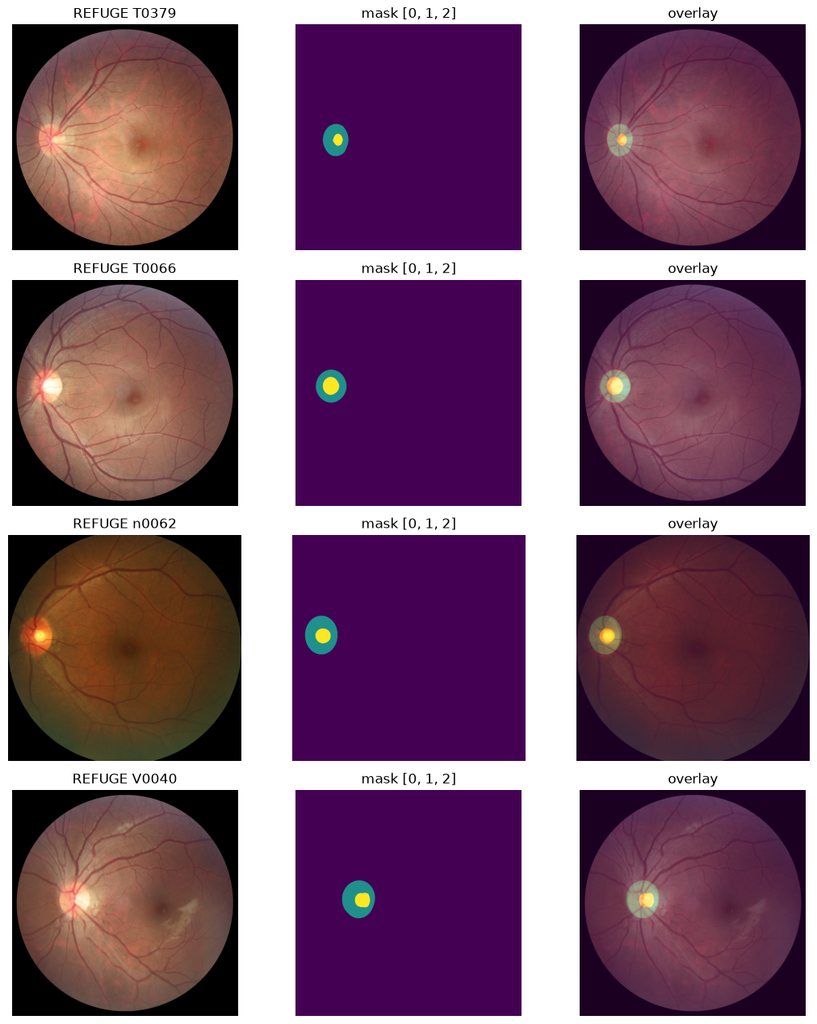

|  | source_dataset | file_id | image_size | mask_shape | sizes_match | mask_unique_values |
| --- | --- | --- | --- | --- | --- | --- |
| 0 | REFUGE | T0379 | (1634, 1634) | (1634, 1634) | True | [0, 1, 2] |
| 1 | REFUGE | T0066 | (1634, 1634) | (1634, 1634) | True | [0, 1, 2] |
| 2 | REFUGE | n0062 | (2124, 2056) | (2056, 2124) | True | [0, 1, 2] |
| 3 | REFUGE | V0040 | (1634, 1634) | (1634, 1634) | True | [0, 1, 2] |

```python
# 02.21 — REFUGE visual QA sample

refuge_visual_qa = visual_qa_sample(
    manifest_df=refuge_manifest,
    source_slug="refuge",
    n=4,
)

refuge_visual_qa
```

## 02.22 — PAPILA manifest

PAPILA stores expert contours rather than raster masks. This section rasterizes disc and cup contours into `{0,1,2}` masks.

The split group is patient-level so right/left eye records from the same patient stay together.

```python
# 02.23 — PAPILA contour rasterization helpers

def read_contour_points(path: Path) -> list[tuple[float, float]]:
    points: list[tuple[float, float]] = []

    with open(path, errors="replace") as file:
        for line in file:
            parts = line.split()
            if len(parts) < 2:
                continue
            try:
                points.append((float(parts[0]), float(parts[1])))
            except ValueError:
                continue

    return points

def fill_polygon(points: list[tuple[float, float]], height: int, width: int) -> np.ndarray:
    canvas = Image.new("L", (width, height), 0)

    if len(points) >= 3:
        ImageDraw.Draw(canvas).polygon(points, outline=1, fill=1)

    return np.asarray(canvas, dtype=bool)

def infer_papila_patient_id(stem: str) -> str:
    if stem.endswith("OD") or stem.endswith("OS"):
        return stem[:-2]
    return stem
```

```python
# 02.24 — Build PAPILA segmentation manifest

papila_manifest_rows = []
papila_rasterization_rows = []
papila_skipped_rows = []

if papila_root is None:
    papila_image_dir = None
    papila_contour_dir = None
else:
    papila_image_dir = papila_root / "FundusImages"
    papila_contour_dir = papila_root / "ExpertsSegmentations" / "Contours"

if papila_image_dir and papila_contour_dir:
    for image_path in sorted(papila_image_dir.iterdir()):
        if not image_path.is_file() or image_path.suffix.lower() not in IMAGE_EXTENSIONS:
            continue

        stem = image_path.stem
        disc_contour_path = papila_contour_dir / f"{stem}_disc_exp{EXPERT}.txt"
        cup_contour_path = papila_contour_dir / f"{stem}_cup_exp{EXPERT}.txt"

        if not (disc_contour_path.exists() and cup_contour_path.exists()):
            papila_skipped_rows.append(
                {
                    "file_id": stem,
                    "reason": "missing_disc_or_cup_contour",
                    "disc_contour_exists": disc_contour_path.exists(),
                    "cup_contour_exists": cup_contour_path.exists(),
                }
            )
            continue

        with Image.open(image_path) as image:
            width, height = image.size

        mask = np.zeros((height, width), dtype=np.uint8)
        mask[fill_polygon(read_contour_points(disc_contour_path), height, width)] = 1
        mask[fill_polygon(read_contour_points(cup_contour_path), height, width)] = 2

        mask_path = PAPILA_MASK_DIR / f"{stem}_exp{EXPERT}.png"
        Image.fromarray(mask).save(mask_path)

        patient_id = infer_papila_patient_id(stem)

        papila_rasterization_rows.append(
            {
                "file_id": stem,
                "expert": EXPERT,
                "patient_id": patient_id,
                "image_size": (width, height),
                "mask_shape": mask.shape,
                "mask_unique_values": sorted(np.unique(mask).astype(int).tolist()),
                "mask_path": project_relative(mask_path),
            }
        )

        papila_manifest_rows.append(
            manifest_row(
                dataset_key="papila",
                source_dataset="PAPILA",
                file_id=stem,
                image_abs=image_path,
                mask_abs=mask_path,
                split_group_id=f"PAPILA_{patient_id}",
                qa_status="rasterized_and_visual_sample_reviewed",
                notes=f"PAPILA mask rasterized from expert {EXPERT} disc/cup contours into project {{0,1,2}} convention.",
                extra={
                    "expert": EXPERT,
                    "patient_id": patient_id,
                    "mask_source": "rasterized_from_contours",
                },
            )
        )

papila_manifest = pd.DataFrame(papila_manifest_rows)
if not papila_manifest.empty:
    papila_manifest = papila_manifest[MANIFEST_COLUMNS + ["expert", "patient_id", "mask_source"]]

papila_manifest_path = MANIFEST_DIR / "papila_segmentation_manifest.csv"
papila_rasterization_path = REPORTS_DIR / "papila_rasterization_summary.csv"
papila_skipped_path = REPORTS_DIR / "papila_skipped_images.csv"

papila_manifest.to_csv(papila_manifest_path, index=False)
pd.DataFrame(papila_rasterization_rows).to_csv(papila_rasterization_path, index=False)
pd.DataFrame(papila_skipped_rows).to_csv(papila_skipped_path, index=False)

display(
    pd.DataFrame(
        [
            {
                "source_dataset": "PAPILA",
                "rows": len(papila_manifest),
                "skipped": len(papila_skipped_rows),
                "expert": EXPERT,
                "papila_root": str(papila_root.relative_to(PROJECT_ROOT)) if papila_root else "[not found]",
            }
        ]
    )
)
display(papila_manifest.head())
```

|  | source_dataset | rows | skipped | expert | papila_root |
| --- | --- | --- | --- | --- | --- |
| 0 | PAPILA | 488 | 0 | 1 | data/external/kaggle/papila/PapilaDB-PAPILA-17f8fa7746adb20275b5b6a0d99dc9dfe3007e9f |

|  | dataset_key | source_dataset | file_id | image_path | mask_path | image_relative_path | mask_relative_path | image_file_name | mask_file_name | mask_encoding | background_value | structure_value_1 | structure_value_2 | split_group_id | include_in_first_pass | qa_status | notes | expert | patient_id | mask_source |
| --- | --- | --- | --- | --- | --- | --- | --- | --- | --- | --- | --- | --- | --- | --- | --- | --- | --- | --- | --- | --- |
| 0 | papila | PAPILA | RET002OD | data/external/kaggle/papila/PapilaDB-PAPILA-17f8fa7746adb20275b5b6a0d99dc9dfe3007e9f/FundusImages/RET002OD.jpg | data/processed/papila_masks/RET002OD_exp1.png | data/external/kaggle/papila/PapilaDB-PAPILA-17f8fa7746adb20275b5b6a0d99dc9dfe3007e9f/FundusImages/RET002OD.jpg | data/processed/papila_masks/RET002OD_exp1.png | RET002OD.jpg | RET002OD_exp1.png | multiclass_values_0_1_2 | 0 | 1 | 2 | PAPILA_RET002 | True | rasterized_and_visual_sample_reviewed | PAPILA mask rasterized from expert 1 disc/cup contours into project {0,1,2} convention. | 1 | RET002 | rasterized_from_contours |
| 1 | papila | PAPILA | RET002OS | data/external/kaggle/papila/PapilaDB-PAPILA-17f8fa7746adb20275b5b6a0d99dc9dfe3007e9f/FundusImages/RET002OS.jpg | data/processed/papila_masks/RET002OS_exp1.png | data/external/kaggle/papila/PapilaDB-PAPILA-17f8fa7746adb20275b5b6a0d99dc9dfe3007e9f/FundusImages/RET002OS.jpg | data/processed/papila_masks/RET002OS_exp1.png | RET002OS.jpg | RET002OS_exp1.png | multiclass_values_0_1_2 | 0 | 1 | 2 | PAPILA_RET002 | True | rasterized_and_visual_sample_reviewed | PAPILA mask rasterized from expert 1 disc/cup contours into project {0,1,2} convention. | 1 | RET002 | rasterized_from_contours |
| 2 | papila | PAPILA | RET004OD | data/external/kaggle/papila/PapilaDB-PAPILA-17f8fa7746adb20275b5b6a0d99dc9dfe3007e9f/FundusImages/RET004OD.jpg | data/processed/papila_masks/RET004OD_exp1.png | data/external/kaggle/papila/PapilaDB-PAPILA-17f8fa7746adb20275b5b6a0d99dc9dfe3007e9f/FundusImages/RET004OD.jpg | data/processed/papila_masks/RET004OD_exp1.png | RET004OD.jpg | RET004OD_exp1.png | multiclass_values_0_1_2 | 0 | 1 | 2 | PAPILA_RET004 | True | rasterized_and_visual_sample_reviewed | PAPILA mask rasterized from expert 1 disc/cup contours into project {0,1,2} convention. | 1 | RET004 | rasterized_from_contours |
| 3 | papila | PAPILA | RET004OS | data/external/kaggle/papila/PapilaDB-PAPILA-17f8fa7746adb20275b5b6a0d99dc9dfe3007e9f/FundusImages/RET004OS.jpg | data/processed/papila_masks/RET004OS_exp1.png | data/external/kaggle/papila/PapilaDB-PAPILA-17f8fa7746adb20275b5b6a0d99dc9dfe3007e9f/FundusImages/RET004OS.jpg | data/processed/papila_masks/RET004OS_exp1.png | RET004OS.jpg | RET004OS_exp1.png | multiclass_values_0_1_2 | 0 | 1 | 2 | PAPILA_RET004 | True | rasterized_and_visual_sample_reviewed | PAPILA mask rasterized from expert 1 disc/cup contours into project {0,1,2} convention. | 1 | RET004 | rasterized_from_contours |
| 4 | papila | PAPILA | RET005OD | data/external/kaggle/papila/PapilaDB-PAPILA-17f8fa7746adb20275b5b6a0d99dc9dfe3007e9f/FundusImages/RET005OD.jpg | data/processed/papila_masks/RET005OD_exp1.png | data/external/kaggle/papila/PapilaDB-PAPILA-17f8fa7746adb20275b5b6a0d99dc9dfe3007e9f/FundusImages/RET005OD.jpg | data/processed/papila_masks/RET005OD_exp1.png | RET005OD.jpg | RET005OD_exp1.png | multiclass_values_0_1_2 | 0 | 1 | 2 | PAPILA_RET005 | True | rasterized_and_visual_sample_reviewed | PAPILA mask rasterized from expert 1 disc/cup contours into project {0,1,2} convention. | 1 | RET005 | rasterized_from_contours |

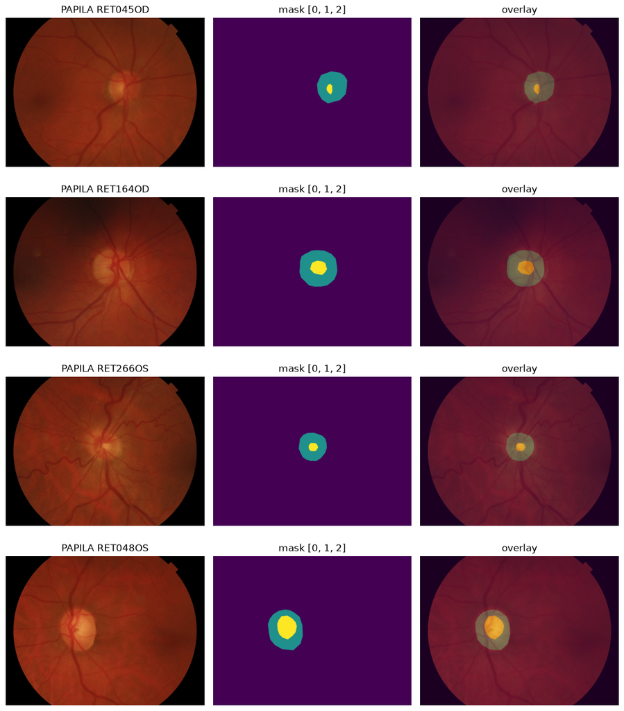

|  | source_dataset | file_id | image_size | mask_shape | sizes_match | mask_unique_values |
| --- | --- | --- | --- | --- | --- | --- |
| 0 | PAPILA | RET045OD | (2576, 1934) | (1934, 2576) | True | [0, 1, 2] |
| 1 | PAPILA | RET164OD | (2576, 1934) | (1934, 2576) | True | [0, 1, 2] |
| 2 | PAPILA | RET266OS | (2576, 1934) | (1934, 2576) | True | [0, 1, 2] |
| 3 | PAPILA | RET048OS | (2576, 1934) | (1934, 2576) | True | [0, 1, 2] |

```python
# 02.25 — PAPILA visual QA sample

papila_visual_qa = visual_qa_sample(
    manifest_df=papila_manifest,
    source_slug="papila",
    n=4,
)

papila_visual_qa
```

## 02.26 — Split assignment for all source manifests

This section applies leakage-aware group splits to ORIGA, G1020, and PAPILA.

REFUGE uses its official split by default.

```python
# 02.27 — Source split helper

def apply_source_split(
    *,
    source_slug: str,
    source_name: str,
    manifest_df: pd.DataFrame,
    mode: str = "group_random",
    official_split_col: str | None = None,
) -> tuple[pd.DataFrame, pd.DataFrame, pd.DataFrame]:
    if manifest_df.empty:
        manifest_with_splits = manifest_df.copy()
        manifest_with_splits["split"] = pd.Series(dtype=str)
        split_assignments = pd.DataFrame(columns=["split_group_id", "split"])
        validation = pd.DataFrame(
            [
                {
                    "source_dataset": source_name,
                    "check": "manifest_is_nonempty",
                    "passed": False,
                    "value": 0,
                    "expected": ">0",
                }
            ]
        )
    elif mode == "official":
        if official_split_col is None or official_split_col not in manifest_df.columns:
            raise ValueError(f"{source_name} requested official split mode but no valid official split column was supplied.")

        manifest_with_splits = manifest_df.assign(split=manifest_df[official_split_col].astype(str))

        split_assignments = (
            manifest_with_splits[["split_group_id", "split"]]
            .drop_duplicates()
            .sort_values("split_group_id")
            .reset_index(drop=True)
        )

        validation = validate_split_assignment(
            manifest_before=manifest_df,
            manifest_after=manifest_with_splits,
            source_name=source_name,
        )
    elif mode == "group_random":
        manifest_with_splits = assign_grouped_splits(manifest_df, config=SPLIT_CONFIG)

        split_assignments = (
            manifest_with_splits[["split_group_id", "split"]]
            .drop_duplicates()
            .sort_values("split_group_id")
            .reset_index(drop=True)
        )

        validation = validate_split_assignment(
            manifest_before=manifest_df,
            manifest_after=manifest_with_splits,
            source_name=source_name,
        )
    else:
        raise ValueError(f"Unknown split mode for {source_name}: {mode}")

    split_assignments_path = SPLIT_DIR / f"{source_slug}_split_assignments.csv"
    validation_path = SPLIT_DIR / f"{source_slug}_split_validation_summary.csv"
    manifest_with_splits_path = MANIFEST_DIR / f"{source_slug}_segmentation_manifest_with_splits.csv"

    split_assignments.to_csv(split_assignments_path, index=False)
    validation.to_csv(validation_path, index=False)
    manifest_with_splits.to_csv(manifest_with_splits_path, index=False)

    return manifest_with_splits, split_assignments, validation
```

```python
# 02.28 — Apply source split strategies

g1020_manifest_with_splits, g1020_split_assignments, g1020_split_validation = apply_source_split(
    source_slug="g1020",
    source_name="G1020",
    manifest_df=g1020_manifest,
    mode="group_random",
)

refuge_manifest_with_splits, refuge_split_assignments, refuge_split_validation = apply_source_split(
    source_slug="refuge",
    source_name="REFUGE",
    manifest_df=refuge_manifest,
    mode=REFUGE_MODE,
    official_split_col="refuge_official_split",
)

papila_manifest_with_splits, papila_split_assignments, papila_split_validation = apply_source_split(
    source_slug="papila",
    source_name="PAPILA",
    manifest_df=papila_manifest,
    mode="group_random",
)

all_split_validation = pd.concat(
    [
        origa_split_validation,
        g1020_split_validation,
        refuge_split_validation,
        papila_split_validation,
    ],
    ignore_index=True,
)

all_split_validation_path = SPLIT_DIR / "all_source_split_validation_summary.csv"
all_split_validation.to_csv(all_split_validation_path, index=False)

all_split_validation
```

|  | source_dataset | check | passed | value | expected |
| --- | --- | --- | --- | --- | --- |
| 0 | ORIGA | manifest_row_count_preserved | True | 650 | 650 |
| 1 | ORIGA | no_missing_split_assignments | True | 0 | 0 |
| 2 | ORIGA | no_split_group_crosses_splits | True | 0 | 0 |
| 3 | G1020 | manifest_row_count_preserved | True | 1020 | 1020 |
| 4 | G1020 | no_missing_split_assignments | True | 0 | 0 |
| 5 | G1020 | no_split_group_crosses_splits | True | 0 | 0 |
| 6 | REFUGE | manifest_row_count_preserved | True | 1200 | 1200 |
| 7 | REFUGE | no_missing_split_assignments | True | 0 | 0 |
| 8 | REFUGE | no_split_group_crosses_splits | True | 0 | 0 |
| 9 | PAPILA | manifest_row_count_preserved | True | 488 | 488 |
| 10 | PAPILA | no_missing_split_assignments | True | 0 | 0 |
| 11 | PAPILA | no_split_group_crosses_splits | True | 0 | 0 |

```python
# 02.29 — Source-by-split summary table

source_split_summary = (
    pd.concat(
        [
            origa_manifest_with_splits,
            g1020_manifest_with_splits,
            refuge_manifest_with_splits,
            papila_manifest_with_splits,
        ],
        ignore_index=True,
        sort=False,
    )
    .groupby(["source_dataset", "split"])
    .size()
    .unstack(fill_value=0)
    .reindex(columns=["train", "val", "test"])
    .fillna(0)
    .astype(int)
    .reset_index()
)

source_split_summary_path = REPORTS_DIR / "source_split_summary.csv"
source_split_summary.to_csv(source_split_summary_path, index=False)

source_split_summary
```

| split | source_dataset | train | val | test |
| --- | --- | --- | --- | --- |
| 0 | G1020 | 714 | 153 | 153 |
| 1 | ORIGA | 455 | 98 | 97 |
| 2 | PAPILA | 342 | 74 | 72 |
| 3 | REFUGE | 400 | 400 | 400 |

## 02.30 — Combined segmentation manifest

The combined manifest is the training-facing artifact for Notebook `03`.

It contains all available first-pass public segmentation sources with a shared core schema.

```python
# 02.31 — Build combined segmentation manifest with splits

split_manifests = [
    origa_manifest_with_splits,
    g1020_manifest_with_splits,
    refuge_manifest_with_splits,
    papila_manifest_with_splits,
]

combined_manifest = pd.concat(
    [manifest[CORE_COMBINED_COLUMNS] for manifest in split_manifests if not manifest.empty],
    ignore_index=True,
    sort=False,
)

combined_manifest_path = MANIFEST_DIR / "combined_segmentation_manifest_with_splits.csv"
combined_manifest.to_csv(combined_manifest_path, index=False)

combined_summary = (
    combined_manifest
    .groupby(["source_dataset", "split"])
    .size()
    .unstack(fill_value=0)
    .reindex(columns=["train", "val", "test"])
    .fillna(0)
    .astype(int)
)

display(pd.DataFrame([{"combined_manifest_rows": len(combined_manifest), "path": str(combined_manifest_path.relative_to(PROJECT_ROOT))}]))
display(combined_summary)
```

|  | combined_manifest_rows | path |
| --- | --- | --- |
| 0 | 3358 | data/processed/manifests/combined_segmentation_manifest_with_splits.csv |

| split source_dataset | train | val | test |
| --- | --- | --- | --- |
| G1020 | 714 | 153 | 153 |
| ORIGA | 455 | 98 | 97 |
| PAPILA | 342 | 74 | 72 |
| REFUGE | 400 | 400 | 400 |

```python
# 02.32 — Validate combined manifest path resolution

path_check_rows = []

for row in combined_manifest.itertuples(index=False):
    image_path = PROJECT_ROOT / row.image_path
    mask_path = PROJECT_ROOT / row.mask_path

    path_check_rows.append(
        {
            "source_dataset": row.source_dataset,
            "file_id": row.file_id,
            "path_type": "image",
            "relative_path": row.image_path,
            "exists": image_path.exists(),
        }
    )
    path_check_rows.append(
        {
            "source_dataset": row.source_dataset,
            "file_id": row.file_id,
            "path_type": "mask",
            "relative_path": row.mask_path,
            "exists": mask_path.exists(),
        }
    )

combined_path_check = pd.DataFrame(path_check_rows)
combined_missing_paths = combined_path_check[~combined_path_check["exists"]].copy()

combined_path_check_path = REPORTS_DIR / "combined_manifest_path_check.csv"
combined_missing_paths_path = REPORTS_DIR / "combined_manifest_missing_paths.csv"

combined_path_check.to_csv(combined_path_check_path, index=False)
combined_missing_paths.to_csv(combined_missing_paths_path, index=False)

combined_path_summary = (
    combined_path_check
    .groupby(["source_dataset", "path_type"])["exists"]
    .agg(["count", "sum"])
    .reset_index()
    .rename(columns={"count": "n_paths", "sum": "n_existing_paths"})
)
combined_path_summary["n_missing_paths"] = combined_path_summary["n_paths"] - combined_path_summary["n_existing_paths"]

display(combined_path_summary)
display(combined_missing_paths.head(10))
```

|  | source_dataset | path_type | n_paths | n_existing_paths | n_missing_paths |
| --- | --- | --- | --- | --- | --- |
| 0 | G1020 | image | 1020 | 1020 | 0 |
| 1 | G1020 | mask | 1020 | 1020 | 0 |
| 2 | ORIGA | image | 650 | 650 | 0 |
| 3 | ORIGA | mask | 650 | 650 | 0 |
| 4 | PAPILA | image | 488 | 488 | 0 |
| 5 | PAPILA | mask | 488 | 488 | 0 |
| 6 | REFUGE | image | 1200 | 1200 | 0 |
| 7 | REFUGE | mask | 1200 | 1200 | 0 |

|  | source_dataset | file_id | path_type | relative_path | exists |
| --- | --- | --- | --- | --- | --- |

## 02.33 — Dataloader smoke test

This section verifies that the project dataloader can read the combined split-aware manifest and produce batches for train, validation, and test.

This is intentionally a smoke test only. It does not train or evaluate a model.

```python
# 02.34 — Build dataloaders from combined manifest

SMOKE_IMAGE_SIZE = (256, 256)
SMOKE_BATCH_SIZE = 4
SMOKE_NUM_WORKERS = 0

dataloader_smoke_status = {
    "ran": False,
    "passed": False,
    "error_type": "",
    "error_message": "",
}

loaders = {}

def normalize_dataloader_output(raw_loaders):
    """Normalize project dataloader output to a {'train', 'val', 'test'} dict."""

    if isinstance(raw_loaders, dict):
        return raw_loaders

    if hasattr(raw_loaders, "_asdict"):
        return raw_loaders._asdict()

    loader_aliases = {
        "train": ["train", "train_loader", "train_dataloader"],
        "val": ["val", "valid", "validation", "val_loader", "valid_loader", "validation_loader", "val_dataloader"],
        "test": ["test", "test_loader", "test_dataloader"],
    }

    normalized = {}

    for split_name, possible_attrs in loader_aliases.items():
        for attr_name in possible_attrs:
            if hasattr(raw_loaders, attr_name):
                candidate_loader = getattr(raw_loaders, attr_name)
                if candidate_loader is not None:
                    normalized[split_name] = candidate_loader
                    break

    return normalized

if len(combined_missing_paths) == 0 and not combined_manifest.empty:
    try:
        loader_signature = inspect.signature(make_segmentation_dataloaders)
        accepted_parameters = set(loader_signature.parameters)

        candidate_loader_kwargs = {
            "manifest_path": combined_manifest_path,
            "image_size": SMOKE_IMAGE_SIZE,
            "batch_size": SMOKE_BATCH_SIZE,
            "num_workers": SMOKE_NUM_WORKERS,
            "train_split": "train",
            "val_split": "val",
            "test_split": "test",
            "train_augmentation_preset": "none",
            "eval_augmentation_preset": "none",
            "normalize": "imagenet",
            "validate_files": True,
            "return_metadata": False,
        }

        loader_kwargs = {
            key: value
            for key, value in candidate_loader_kwargs.items()
            if key in accepted_parameters
        }

        raw_loaders = make_segmentation_dataloaders(**loader_kwargs)
        loaders = normalize_dataloader_output(raw_loaders)

        expected_loader_keys = {"train", "val", "test"}
        missing_loader_keys = expected_loader_keys.difference(loaders.keys())

        if missing_loader_keys:
            raise ValueError(
                f"Dataloader output is missing expected split keys: "
                f"{sorted(missing_loader_keys)}. "
                f"Raw output type: {type(raw_loaders).__name__}."
            )

        dataloader_smoke_status["ran"] = True
        dataloader_smoke_status["passed"] = True

    except Exception as exc:
        loaders = {}
        dataloader_smoke_status["ran"] = True
        dataloader_smoke_status["passed"] = False
        dataloader_smoke_status["error_type"] = type(exc).__name__
        dataloader_smoke_status["error_message"] = str(exc)
else:
    loaders = {}
    dataloader_smoke_status["ran"] = False
    dataloader_smoke_status["passed"] = False
    dataloader_smoke_status["error_type"] = "PreflightBlocked"
    dataloader_smoke_status["error_message"] = (
        "Combined manifest is empty or contains missing image/mask paths."
    )

pd.DataFrame([dataloader_smoke_status])
```

|  | ran | passed | error_type | error_message |
| --- | --- | --- | --- | --- |
| 0 | True | True |  |  |

```python
# 02.35 — Inspect one batch from each dataloader

batch_summary_rows = []

if dataloader_smoke_status["passed"]:
    for split_name, loader in loaders.items():
        batch = next(iter(loader))

        images = batch["image"]
        masks = batch["mask"]

        batch_summary_rows.append(
            {
                "split": split_name,
                "dataset_length": len(loader.dataset),
                "batch_image_shape": tuple(images.shape),
                "batch_image_dtype": str(images.dtype),
                "batch_mask_shape": tuple(masks.shape),
                "batch_mask_dtype": str(masks.dtype),
                "batch_mask_unique_values": sorted(torch.unique(masks).cpu().numpy().astype(int).tolist()),
            }
        )

batch_summary_df = pd.DataFrame(batch_summary_rows)
batch_summary_path = REPORTS_DIR / "dataloader_smoke_test_summary.csv"
batch_summary_df.to_csv(batch_summary_path, index=False)

batch_summary_df
```

|  | split | dataset_length | batch_image_shape | batch_image_dtype | batch_mask_shape | batch_mask_dtype | batch_mask_unique_values |
| --- | --- | --- | --- | --- | --- | --- | --- |
| 0 | train | 1911 | (4, 3, 256, 256) | torch.float32 | (4, 256, 256) | torch.int64 | [0, 1, 2] |
| 1 | val | 725 | (4, 3, 256, 256) | torch.float32 | (4, 256, 256) | torch.int64 | [0, 1, 2] |
| 2 | test | 722 | (4, 3, 256, 256) | torch.float32 | (4, 256, 256) | torch.int64 | [0, 1, 2] |

```python
# 02.36 — Notebook 02 output inventory

expected_output_paths = {
    "origa_manifest_with_splits": MANIFEST_DIR / "origa_segmentation_manifest_with_splits.csv",
    "g1020_manifest": MANIFEST_DIR / "g1020_segmentation_manifest.csv",
    "g1020_manifest_with_splits": MANIFEST_DIR / "g1020_segmentation_manifest_with_splits.csv",
    "refuge_manifest": MANIFEST_DIR / "refuge_segmentation_manifest.csv",
    "refuge_manifest_with_splits": MANIFEST_DIR / "refuge_segmentation_manifest_with_splits.csv",
    "papila_manifest": MANIFEST_DIR / "papila_segmentation_manifest.csv",
    "papila_manifest_with_splits": MANIFEST_DIR / "papila_segmentation_manifest_with_splits.csv",
    "combined_manifest_with_splits": MANIFEST_DIR / "combined_segmentation_manifest_with_splits.csv",
    "all_source_split_validation": SPLIT_DIR / "all_source_split_validation_summary.csv",
    "source_split_summary": REPORTS_DIR / "source_split_summary.csv",
    "combined_manifest_path_check": REPORTS_DIR / "combined_manifest_path_check.csv",
    "dataloader_smoke_test_summary": REPORTS_DIR / "dataloader_smoke_test_summary.csv",
}

output_inventory_df = pd.DataFrame(
    [
        {
            "artifact": artifact_name,
            "path": str(artifact_path.relative_to(PROJECT_ROOT)),
            "exists": artifact_path.exists(),
            "size_bytes": artifact_path.stat().st_size if artifact_path.exists() else 0,
        }
        for artifact_name, artifact_path in expected_output_paths.items()
    ]
)

output_inventory_df
```

|  | artifact | path | exists | size_bytes |
| --- | --- | --- | --- | --- |
| 0 | origa_manifest_with_splits | data/processed/manifests/origa_segmentation_manifest_with_splits.csv | True | 302209 |
| 1 | g1020_manifest | data/processed/manifests/g1020_segmentation_manifest.csv | True | 548278 |
| 2 | g1020_manifest_with_splits | data/processed/manifests/g1020_segmentation_manifest_with_splits.csv | True | 553945 |
| 3 | refuge_manifest | data/processed/manifests/refuge_segmentation_manifest.csv | True | 677068 |
| 4 | refuge_manifest_with_splits | data/processed/manifests/refuge_segmentation_manifest_with_splits.csv | True | 683074 |
| 5 | papila_manifest | data/processed/manifests/papila_segmentation_manifest.csv | True | 282828 |
| 6 | papila_manifest_with_splits | data/processed/manifests/papila_segmentation_manifest_with_splits.csv | True | 285542 |
| 7 | combined_manifest_with_splits | data/processed/manifests/combined_segmentation_manifest_with_splits.csv | True | 681541 |
| 8 | all_source_split_validation | data/processed/splits/all_source_split_validation_summary.csv | True | 601 |
| 9 | source_split_summary | reports/data_audit/source_split_summary.csv | True | 100 |
| 10 | combined_manifest_path_check | reports/data_audit/combined_manifest_path_check.csv | True | 636650 |
| 11 | dataloader_smoke_test_summary | reports/data_audit/dataloader_smoke_test_summary.csv | True | 363 |

```python
# 02.37 — Notebook 02 handoff summary

all_expected_outputs_exist = bool(output_inventory_df["exists"].all())
all_split_checks_passed = bool(all_split_validation["passed"].all()) if not all_split_validation.empty else False
all_paths_resolve = len(combined_missing_paths) == 0
dataloader_smoke_passed = bool(dataloader_smoke_status["passed"])

next_notebook_ready = (
    all_expected_outputs_exist
    and all_split_checks_passed
    and all_paths_resolve
    and dataloader_smoke_passed
)

handoff_summary_df = pd.DataFrame(
    [
        {
            "item": "ORIGA split manifest",
            "status": "OK" if (MANIFEST_DIR / "origa_segmentation_manifest_with_splits.csv").exists() else "CHECK",
            "notes": "ORIGA has leakage-aware train/val/test split assignments.",
        },
        {
            "item": "Additional source manifests",
            "status": "OK" if all(
                [
                    (MANIFEST_DIR / "g1020_segmentation_manifest.csv").exists(),
                    (MANIFEST_DIR / "refuge_segmentation_manifest.csv").exists(),
                    (MANIFEST_DIR / "papila_segmentation_manifest.csv").exists(),
                ]
            ) else "CHECK",
            "notes": "G1020, REFUGE, and PAPILA manifests are represented in the same project schema.",
        },
        {
            "item": "All source split validation",
            "status": "OK" if all_split_checks_passed else "CHECK",
            "notes": "No missing split assignments and no split-group leakage.",
        },
        {
            "item": "Combined split manifest",
            "status": "OK" if combined_manifest_path.exists() and len(combined_manifest) > 0 else "CHECK",
            "notes": f"Combined manifest rows: {len(combined_manifest)}.",
        },
        {
            "item": "Combined path validation",
            "status": "OK" if all_paths_resolve else "CHECK",
            "notes": f"Missing image/mask paths: {len(combined_missing_paths)}.",
        },
        {
            "item": "Dataloader smoke test",
            "status": "OK" if dataloader_smoke_passed else "CHECK",
            "notes": "Train/val/test dataloaders produced at least one batch." if dataloader_smoke_passed else dataloader_smoke_status["error_message"],
        },
        {
            "item": "Next notebook",
            "status": "READY" if next_notebook_ready else "BLOCKED",
            "notes": "Proceed to 03_baseline_unet_reproduction.ipynb." if next_notebook_ready else "Resolve CHECK items before moving to model training.",
        },
    ]
)

handoff_summary_df
```

|  | item | status | notes |
| --- | --- | --- | --- |
| 0 | ORIGA split manifest | OK | ORIGA has leakage-aware train/val/test split assignments. |
| 1 | Additional source manifests | OK | G1020, REFUGE, and PAPILA manifests are represented in the same project schema. |
| 2 | All source split validation | OK | No missing split assignments and no split-group leakage. |
| 3 | Combined split manifest | OK | Combined manifest rows: 3358. |
| 4 | Combined path validation | OK | Missing image/mask paths: 0. |
| 5 | Dataloader smoke test | OK | Train/val/test dataloaders produced at least one batch. |
| 6 | Next notebook | READY | Proceed to 03_baseline_unet_reproduction.ipynb. |